# Exercício Litteris

Luis Antonio

# Introdução

# Questões

1. Quais gêneros tem na média histórica os maiores ratings
2. Quais gêneros obtiveram a maior queda e crescimento na média com o passar do tempo
3. Existe alguma relação entre users? (e.g. users dão notas mais altas para um gênero dão notas mais baixas para outro gênero; dica: você pode tentar segmentar users)

Os dados utilizados para responder as questões estão no link abaixo. http://grouplens.org/datasets/movielens/20m/

A partir dele foram retirados dois arquivos úteis, e foram criados dois data frames, `movies` e `ratings`. Abaixo vemos parte deles.

Head of the Movies Data Frame

| movieId | title | genres |
| --- | --- | --- |
| 1 | Toy Story (1995) | Adventure\|Animation\|Children\|Comedy\|Fantasy |
| 2 | Jumanji (1995) | Adventure\|Children\|Fantasy |
| 3 | Grumpier Old Men (1995) | Comedy\|Romance |

Head of the Ratings Data Frame

| userId | movieId | rating | timestamp |
| --- | --- | --- | --- |
| 1 | 2 | 3.5 | 1112486027 |
| 1 | 29 | 3.5 | 1112484676 |
| 1 | 32 | 3.5 | 1112484819 |

# Processamento dos data frames

Como alguns filmes possuem vários gêneros, separamos os diferentes gêneros em diferentes linhas.

Movies com gêneros separados

| movieId | title | genres |
| --- | --- | --- |
| 1 | Toy Story (1995) | Adventure |
| 1 | Toy Story (1995) | Animation |
| 1 | Toy Story (1995) | Children |
| 1 | Toy Story (1995) | Comedy |
| 1 | Toy Story (1995) | Fantasy |

Para obtermos os gêneros e seus respectivos ratings criamos um único data frame fazendo inner join de `ratings` e `movies`, usando o campo `movieId`.

Data frame completo

| userId | movieId | rating | timestamp | title | genres |
| --- | --- | --- | --- | --- | --- |
| 1 | 2 | 3.5 | 2005 | Jumanji (1995) | Adventure |
| 1 | 2 | 3.5 | 2005 | Jumanji (1995) | Children |
| 1 | 2 | 3.5 | 2005 | Jumanji (1995) | Fantasy |
| 1 | 29 | 3.5 | 2005 | City of Lost Children, The (Cité des enfants perdus, La) (1995) | Adventure |
| 1 | 29 | 3.5 | 2005 | City of Lost Children, The (Cité des enfants perdus, La) (1995) | Drama |

# Outliers:

Foi excluído o ano de 1995, pois existem apenas 4 filmes nesse ano.

| movieId | title | genres |
| --- | --- | --- |
| 21 | Get Shorty (1995) | Comedy\|Crime\|Thriller |
| 47 | Seven (a.k.a. Se7en) (1995) | Mystery\|Thriller |
| 1079 | Fish Called Wanda, A (1988) | Comedy\|Crime |
| 1176 | Double Life of Veronique, The (Double Vie de Véronique, La) (1991) | Drama\|Fantasy\|Romance |

# Questão 1

Agrupando a média dos ratings por gênero e tempo.

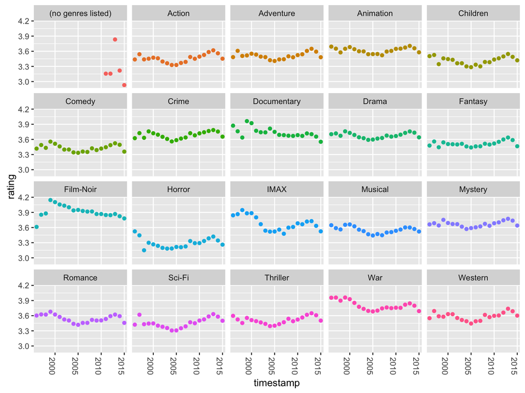

Analisando as maiores médias, abaixo vemos os gêneros com maiores ratings.

| genres | rating |
| --- | --- |
| Film-Noir | 3.911992 |
| War | 3.803397 |
| Documentary | 3.733566 |
| IMAX | 3.683389 |
| Crime | 3.682062 |
| Drama | 3.676133 |

# Questão 2

Para analisar os crescimentos e quedas na média, o data frame foi dividido em 2 períodos (análise visual de crescimento e queda). Mesmo acreditando que deve existir uma maneira melhor…

```r
cresc <- tout %>% filter(timestamp %in% c(2005:2013) & genres != "(no genres listed)")
queda <- tout %>% filter(timestamp %in% c(1999:2005) & genres != "(no genres listed)")
```

A partir dessa divisão pensei em duas maneiras para descobrir os gêneros com maiores quedas e os com maiores crescimentos. A primeira seria analisando o coeficiente angular da regressão linear.

Crescimento

| genres | slope |
| --- | --- |
| Children | 0.0487146 |
| Western | 0.0449657 |
| Sci-Fi | 0.0429731 |
| Action | 0.0398870 |
| Romance | 0.0377789 |
| IMAX | 0.0372127 |

Queda

[output not shown]

E, a segunda, seria calcular a diferença entre o maior e o menor rating nesses períodos, por gênero. Para isso usei o pacote `sqldf`. Não gerou o mesmo resultado, a ordem não foi a mesma.

Crescimento na média e queda na média.

Crescimento

| genres | diff |
| --- | --- |
| Sci-Fi | 0.3236401 |
| Western | 0.2936069 |
| Action | 0.2905666 |
| Children | 0.2610443 |
| IMAX | 0.2497089 |
| Thriller | 0.2462954 |

Queda

| genres | diff |
| --- | --- |
| IMAX | 0.3660882 |
| War | 0.2755366 |
| Romance | 0.2597686 |
| Documentary | 0.2231839 |
| Comedy | 0.2220157 |
| Musical | 0.2194429 |

# Questão 3

Para realizarmos o gráfico com a correlação entre os gêneros vamos, primeiro, verificar o número de vezes que um usuário forneceu determinado rate para um determinado gênero e a média, agrupando por `(user,genre)`.

Agora, vamos padronizar a coluna de rating, por usuário (alguns usuários que veem mais filmes que outros).

Passamos agora os gênero para colunas para fazermos a correlação. Temos um exemplo abaixo, com as 6 primeiras colunas.

Gêneros nas colunas

| userId | Action | Adventure | Animation | Children | Comedy |
| --- | --- | --- | --- | --- | --- |
| 1 | 0.9108773 | 1.222508 | -0.9810469 | -0.4361182 | 1.0028340 |
| 2 | 2.1958028 | 1.978503 | -0.7739635 | -0.7739635 | -0.2850385 |
| 3 | 0.9943531 | 1.109202 | -0.9287968 | -0.6210328 | 1.1092016 |

Abaixo vemos o gráfico da correlação entre os gêneros.

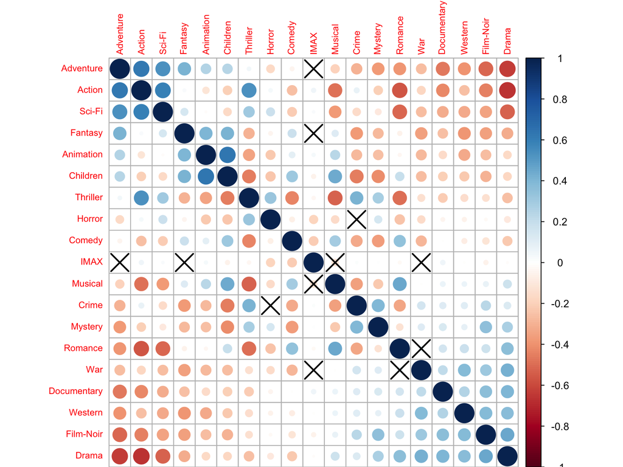

Vemos que, pessoas que gostam de gêneros como Aventura e/ou Ação e/ou Sci-Fi, não gostam de Dramas e/ou Filmes-Noir. E, quem gosta de Filmes-Noir e/ou Drama, não gosta de Aventura e Ação.

Em menor escala, quem gosta de Thriller gosta de Ação e não gosta de Musical ou Romance, quem gosta de Animação gosta de filmes de criança, quem gosta Musical também gosta de filmes de criança e Romance, mas não gosta de filmes de Ação ou Thriller.